# 2. LWL-side item difficulty

peekbank-items

This notebook extracts **word-level difficulty from the LWL task itself**, updating the background item analyses (`3A_trial_level_models`, `4A_predicting_item_variation`) to the 2026.1 data.

The key lesson from the background work: raw per-word accuracy is badly confounded (easy words tested in younger samples) and contaminated by perceptual **salience / animacy** biases. So we model trial-level accuracy with controls and extract animacy-adjusted word random effects as the LWL difficulty measure.

```r
library(here)
library(lme4)
library(ggrepel)
source(here("helper", "common.R"))
knitr::opts_chunk$set(cache = FALSE)

d_trial <- readRDS(here("cached_intermediates", "1_d_trial.Rds"))
```

## Trial-level frame

We use the long window (200–4000 ms) elogit as the dependent variable. Following the background analysis, the main models are fit on trials that are not at floor or ceiling (the smoothed elogit is finite everywhere, but 0/1 trials inflate the tails).

```r
df <- d_trial |>
  ungroup() |>
  rename(accuracy = long_window_accuracy, elogit = long_window_elogit) |>
  filter(!is.na(accuracy))

animates <- c("animal", "baby", "dog", "bear", "bird", "boy", "bunny", "cat",
              "chicken", "cow", "duck", "elephant", "fish", "frog", "giraffe",
              "horse", "kangaroo", "lion", "monkey", "owl", "pig", "puppy",
              "sheep", "teddy", "tiger", "whale", "zebra")

d_acc <- df |>
  filter(accuracy > 0, accuracy < 1) |>
  mutate(
    log_age = log(age),
    log_age_centered = log_age - mean(log_age),
    animate_target = target_label %in% animates,
    animate_distractor = distractor_label %in% animates
  )

words <- d_acc |> count(target_label, name = "n")
```

## Two models: with and without animacy adjustment

```r
# baseline: target/distractor random effects, no animacy fixed effects
mod_base <- lmer(
  elogit ~ log_age_centered +
    (1 | administration_id) +
    (log_age_centered | dataset_name) +
    (log_age_centered | target_label) +
    (1 | distractor_label),
  data = d_acc, control = lmerControl(optimizer = "bobyqa")
)

# animacy-adjusted: removes perceptual salience from the word random effects
mod_acc <- lmer(
  elogit ~ log_age_centered * animate_target +
    log_age_centered * animate_distractor +
    (1 | administration_id) +
    (log_age_centered | dataset_name) +
    (log_age_centered | target_label) +
    (1 | distractor_label),
  data = d_acc, control = lmerControl(optimizer = "bobyqa")
)

knitr::kable(summary(mod_acc)$coefficients, digits = 3)
```

|  | Estimate | Std. Error | t value |
| --- | --- | --- | --- |
| (Intercept) | 0.496 | 0.044 | 11.349 |
| log_age_centered | 0.897 | 0.079 | 11.312 |
| animate_targetTRUE | 0.126 | 0.063 | 2.012 |
| animate_distractorTRUE | -0.179 | 0.056 | -3.222 |
| log_age_centered:animate_targetTRUE | -0.153 | 0.099 | -1.549 |
| log_age_centered:animate_distractorTRUE | 0.262 | 0.062 | 4.228 |

There are sizable animacy biases (animate targets easier, animate distractors harder), larger for younger children — exactly the salience contamination the word random effects need to be purged of.

## Extract LWL word difficulty

We take the **animacy-adjusted target random intercept** as the primary LWL difficulty measure (higher = recognized better), with the random slope on age as a secondary measure. We also keep raw average accuracy/elogit for comparison.

```r
get_target_ranef <- function(mod, label) {
  re <- ranef(mod)$target_label
  tibble(target_label = rownames(re),
         intercept = re[["(Intercept)"]],
         slope = re[["log_age_centered"]]) |>
    rename_with(~ paste0(.x, "_", label), c("intercept", "slope"))
}

lwl_word <- d_acc |>
  group_by(target_label) |>
  summarise(avg_accuracy = mean(accuracy),
            avg_elogit = mean(elogit),
            n_trials = n()) |>
  left_join(get_target_ranef(mod_base, "base"), by = "target_label") |>
  left_join(get_target_ranef(mod_acc, "adj"), by = "target_label")
```

How much does animacy adjustment change the word ranking? (Animate words should move down relative to the unadjusted estimate.)

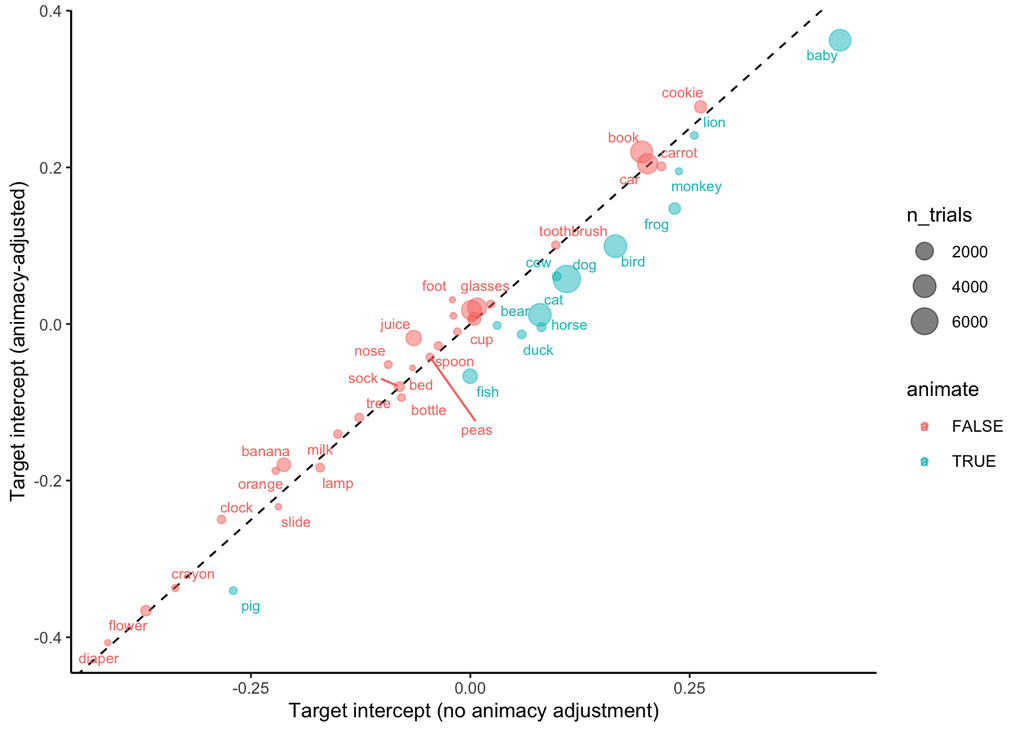

```r
lwl_word |>
  mutate(animate = target_label %in% animates) |>
  filter(n_trials > 100) |>
  ggplot(aes(x = intercept_base, y = intercept_adj, color = animate)) +
  geom_abline(lty = 2) +
  geom_point(aes(size = n_trials), alpha = .5) +
  geom_text_repel(aes(label = target_label), size = 2.5, max.overlaps = 12) +
  xlab("Target intercept (no animacy adjustment)") +
  ylab("Target intercept (animacy-adjusted)")
```

## The distractor matters too

A core background insight: accuracy in this 2AFC task depends on **both** the target and the distractor. The distractor random intercepts capture how “grabby” each word is as a competitor.

```r
distractors <- d_acc |> count(distractor_label, name = "n")
distractor_ranef <- tibble(
  distractor_label = rownames(ranef(mod_acc)$distractor_label),
  distractor_intercept = ranef(mod_acc)$distractor_label[["(Intercept)"]]
) |>
  left_join(distractors, by = "distractor_label")

distractor_ranef |>
  mutate(animate = distractor_label %in% animates) |>
  filter(n > 100) |>
  arrange(distractor_intercept) |>
  head(15) |>
  kable(digits = 2, caption = "Hardest distractors (most grabby competitors)")
```

Hardest distractors (most grabby competitors)

| distractor_label | distractor_intercept | n | animate |
| --- | --- | --- | --- |
| eyes | -0.33 | 112 | FALSE |
| bike | -0.27 | 130 | FALSE |
| cookie | -0.25 | 879 | FALSE |
| carrot | -0.21 | 343 | FALSE |
| lion | -0.13 | 131 | TRUE |
| horse | -0.12 | 228 | TRUE |
| lamp | -0.08 | 288 | FALSE |
| frog | -0.07 | 602 | TRUE |
| dog | -0.05 | 5886 | TRUE |
| cat | -0.04 | 3890 | TRUE |
| peas | -0.04 | 176 | FALSE |
| clock | -0.04 | 230 | FALSE |
| glasses | -0.03 | 157 | FALSE |
| toothbrush | -0.02 | 204 | FALSE |
| foot | -0.02 | 116 | FALSE |

## Save LWL-side measures

```r
saveRDS(
  list(
    lwl_word = lwl_word,                  # per-target-word LWL measures
    distractor_ranef = distractor_ranef,  # per-distractor-word grabbiness
    mod_acc = mod_acc,                    # animacy-adjusted trial model
    d_acc = d_acc,                        # modeling frame
    animates = animates
  ),
  here("cached_intermediates", "2_lwl_item.Rds")
)
```